# Segmentación por agrupamiento

K-means en intensidades y refinamiento de máscaras

Author

Curso de Procesamiento Digital de Imágenes

## 1 Propósito de la sesión

Al finalizar, podrás:

- Aplicar **k-means** para segmentar por similaridad de intensidades.
- Comparar **umbralización** vs **agrupamiento** bajo un mismo caso de estudio.
- Refinar máscaras con operaciones morfológicas simples.
- Argumentar decisiones técnicas pensando en etapas posteriores de **descripción** y **reconocimiento**.

## 2 Marco de la unidad (hilo completo)

En esta unidad, la segmentación se usa para dividir la imagen en regiones significativas:

- **Discontinuidades**: bordes (Sobel, Canny).
- **Similaridad**: umbralización global, Otsu, adaptativa.
- **Agrupamiento**: k-means por intensidades.

Idea clave: la calidad de segmentación impacta directamente la extracción de características y el reconocimiento posterior.

## 3 Puente con la clase anterior

Ya vimos que la umbralización:

- es rápida y fácil de interpretar,
- depende de la iluminación y del histograma,
- puede fallar si no existe un umbral único representativo.

Hoy agregamos una alternativa: **agrupar píxeles en K clases** sin fijar un solo umbral manual.

## 4 K-means: intuición

K-means busca centroides que representen grupos de píxeles similares.

1. Inicializa $K$ centroides.
2. Asigna cada píxel al centroide más cercano.
3. Recalcula centroides.
4. Repite hasta converger.

Objetivo:

$$\min \sum_{k=1}^{K} \sum_{x_i \in C_k} ||x_i - \mu_k||^2$$

En esta sesión: $x_i$ será la intensidad (1D).

## 5 OpenCV: llamada base

`cv2.kmeans(data, K, bestLabels, criteria, attempts, flags)`

Parámetros clave:

- `data`: matriz `float32` de muestras (N x d).
- `K`: número de grupos.
- `criteria`: máx. iteraciones y/o epsilon.
- `attempts`: reinicios para mejorar estabilidad.
- `flags`: inicialización (`cv2.KMEANS_PP_CENTERS` recomendado).

Salida:

- compactness, labels, centers.

## 6 Ejemplo sintético: comparación directa

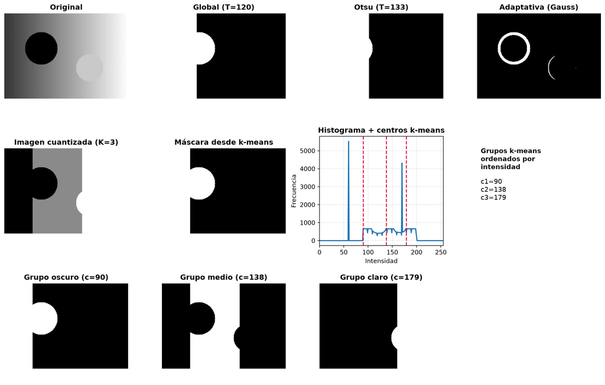

```
Centros (ordenados): [ 90. 138. 179.]
```

```python
import numpy as np
import cv2
import matplotlib.pyplot as plt

# Imagen sintética con gradiente + objetos
H, W = 220, 320
x = np.linspace(0, 1, W)
bg = (90 + 110*x)[None, :].repeat(H, axis=0)
img = bg.copy()

yy, xx = np.ogrid[:H, :W]
mask1 = (yy - 90)**2 + (xx - 95)**2 <= 42**2
mask2 = (yy - 140)**2 + (xx - 220)**2 <= 35**2
img[mask1] = 60
img[mask2] = 170
img = np.clip(img, 0, 255).astype(np.uint8)

# Umbralización (global, Otsu, adaptativa)
_, th_global = cv2.threshold(img, 120, 255, cv2.THRESH_BINARY_INV)
ret_otsu, th_otsu = cv2.threshold(img, 0, 255, cv2.THRESH_BINARY_INV + cv2.THRESH_OTSU)
th_adapt = cv2.adaptiveThreshold(
    img, 255, cv2.ADAPTIVE_THRESH_GAUSSIAN_C, cv2.THRESH_BINARY_INV, 31, 5
)

# K-means en intensidades (K=3)
Z = img.reshape((-1, 1)).astype(np.float32)
criteria = (cv2.TERM_CRITERIA_EPS + cv2.TERM_CRITERIA_MAX_ITER, 30, 0.2)
_, labels, centers = cv2.kmeans(
    Z, 3, None, criteria, 10, cv2.KMEANS_PP_CENTERS
)
centers = np.uint8(centers)
labels2d = labels.reshape(img.shape)
seg_km = centers[labels.flatten()].reshape(img.shape)

# Ordenamos clusters por intensidad para interpretar mejor los grupos
cent_vals = centers.ravel().astype(np.float32)
order = np.argsort(cent_vals)
low_id, mid_id, high_id = order[0], order[1], order[2]

# Tomamos como objeto el cluster de menor intensidad
obj_cluster = int(low_id)
mask_km = (labels2d == obj_cluster).astype(np.uint8) * 255

# Mascaras de cada grupo para visualizacion
mask_low = (labels2d == low_id).astype(np.uint8) * 255
mask_mid = (labels2d == mid_id).astype(np.uint8) * 255
mask_high = (labels2d == high_id).astype(np.uint8) * 255

# Histograma de intensidades y centros de k-means
hist, bins = np.histogram(img.ravel(), bins=256, range=(0, 256))

fig, axs = plt.subplots(3, 4, figsize=(14, 9))
axs[0, 0].imshow(img, cmap="gray")
axs[0, 0].set_title("Original", fontweight="bold")
axs[0, 0].axis("off")

axs[0, 1].imshow(th_global, cmap="gray")
axs[0, 1].set_title("Global (T=120)", fontweight="bold")
axs[0, 1].axis("off")

axs[0, 2].imshow(th_otsu, cmap="gray")
axs[0, 2].set_title(f"Otsu (T={ret_otsu:.0f})", fontweight="bold")
axs[0, 2].axis("off")

axs[0, 3].imshow(th_adapt, cmap="gray")
axs[0, 3].set_title("Adaptativa (Gauss)", fontweight="bold")
axs[0, 3].axis("off")

axs[1, 0].imshow(seg_km, cmap="gray")
axs[1, 0].set_title("Imagen cuantizada (K=3)", fontweight="bold")
axs[1, 0].axis("off")

axs[1, 1].imshow(mask_km, cmap="gray")
axs[1, 1].set_title("Máscara desde k-means", fontweight="bold")
axs[1, 1].axis("off")

axs[1, 2].plot(hist, color="tab:blue", linewidth=1.8)
for c in np.sort(cent_vals):
    axs[1, 2].axvline(c, color="crimson", linestyle="--", linewidth=1.5)
axs[1, 2].set_xlim([0, 255])
axs[1, 2].set_title("Histograma + centros k-means", fontweight="bold")
axs[1, 2].set_xlabel("Intensidad")
axs[1, 2].set_ylabel("Frecuencia")
axs[1, 2].grid(True, alpha=0.25)

axs[1, 3].axis("off")
axs[1, 3].text(
    0.03,
    0.7,
    "Grupos k-means\nordenados por\nintensidad",
    fontsize=11,
    weight="bold",
)
axs[1, 3].text(
    0.03,
    0.42,
    f"c1={cent_vals[low_id]:.0f}\nc2={cent_vals[mid_id]:.0f}\nc3={cent_vals[high_id]:.0f}",
    fontsize=11,
)

axs[2, 0].imshow(mask_low, cmap="gray")
axs[2, 0].set_title(f"Grupo oscuro (c={cent_vals[low_id]:.0f})", fontweight="bold")
axs[2, 0].axis("off")

axs[2, 1].imshow(mask_mid, cmap="gray")
axs[2, 1].set_title(f"Grupo medio (c={cent_vals[mid_id]:.0f})", fontweight="bold")
axs[2, 1].axis("off")

axs[2, 2].imshow(mask_high, cmap="gray")
axs[2, 2].set_title(f"Grupo claro (c={cent_vals[high_id]:.0f})", fontweight="bold")
axs[2, 2].axis("off")

axs[2, 3].axis("off")

plt.tight_layout()
plt.show()

print("Centros (ordenados):", np.sort(cent_vals))
```

## 7 Caso real: `frutas.jpg` con k-means

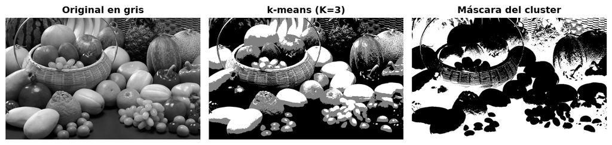

```
Centros (intensidad): [ 45 183 115]
Compactness: 324443148.2198017
```

```python
import cv2
import numpy as np
import matplotlib.pyplot as plt

img_bgr = cv2.imread("imagenes/frutas.jpg")
if img_bgr is None:
    raise FileNotFoundError("No se encontró la imagen en 'imagenes/frutas.jpg'")

img_gray = cv2.cvtColor(img_bgr, cv2.COLOR_BGR2GRAY)

Z = img_gray.reshape((-1, 1)).astype(np.float32)
criteria = (cv2.TERM_CRITERIA_EPS + cv2.TERM_CRITERIA_MAX_ITER, 40, 0.1)
compactness, labels, centers = cv2.kmeans(
    Z, 3, None, criteria, 12, cv2.KMEANS_PP_CENTERS
)

centers = np.uint8(centers)
labels2d = labels.reshape(img_gray.shape)
seg = centers[labels.flatten()].reshape(img_gray.shape)

# Elegimos como objeto el cluster más oscuro (ajustable según imagen)
obj_id = int(np.argmin(centers))
mask = (labels2d == obj_id).astype(np.uint8) * 255

fig, axs = plt.subplots(1, 3, figsize=(11, 5))
axs[0].imshow(img_gray, cmap="gray")
axs[0].set_title("Original en gris", fontweight="bold")
axs[0].axis("off")

axs[1].imshow(seg, cmap="gray")
axs[1].set_title("k-means (K=3)", fontweight="bold")
axs[1].axis("off")

axs[2].imshow(mask, cmap="gray")
axs[2].set_title("Máscara del cluster", fontweight="bold")
axs[2].axis("off")

plt.tight_layout()
plt.show()

print("Centros (intensidad):", centers.ravel())
print("Compactness:", compactness)
```

## 8 Recordatorio: erosión y dilatación

Sobre una máscara binaria (objeto blanco, fondo negro):

- **Erosión**: contrae el objeto. Quita bordes y detalles finos.
- **Dilatación**: expande el objeto. Engrosa bordes y puede unir fragmentos cercanos.

Intuición con el kernel:

- Erosión conserva un píxel blanco solo si su vecindad también es blanca.
- Dilatación vuelve blanco un píxel si al menos parte de su vecindad toca objeto.

## 9 Apertura vs cierre (concepto)

- **Apertura = erosión + dilatación**
  - Primero limpia puntos/ramas finas de ruido.
  - Luego recupera parcialmente el tamaño del objeto.
  - Uso típico: quitar salpicado blanco aislado.
- **Cierre = dilatación + erosión**
  - Primero tapa huecos o cortes pequeños.
  - Luego vuelve a ajustar el contorno.
  - Uso típico: rellenar agujeros negros dentro del objeto.

Regla práctica:

- Ruido blanco pequeño -> probar apertura.
- Huecos negros pequeños -> probar cierre.

## 10 Ejemplo sintético 1: ruido y detalles finos

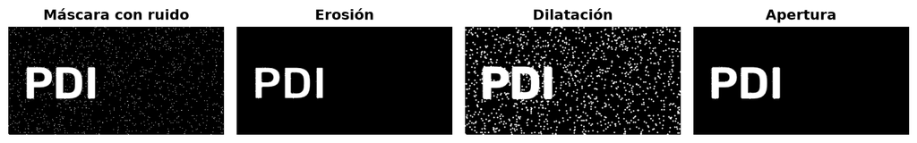

```python
import numpy as np
import cv2
import matplotlib.pyplot as plt

np.random.seed(7)

# Máscara base con texto
mask_txt = np.zeros((180, 360), dtype=np.uint8)
cv2.putText(mask_txt, "PDI", (25, 120), cv2.FONT_HERSHEY_SIMPLEX, 2.6, 255, 7, cv2.LINE_AA)

# Agregamos ruido blanco tipo "sal"
noise = np.random.rand(*mask_txt.shape) < 0.02
mask_noise = mask_txt.copy()
mask_noise[noise] = 255

kernel = cv2.getStructuringElement(cv2.MORPH_ELLIPSE, (3, 3))
eroded = cv2.erode(mask_noise, kernel, iterations=1)
dilated = cv2.dilate(mask_noise, kernel, iterations=1)
opened = cv2.morphologyEx(mask_noise, cv2.MORPH_OPEN, kernel, iterations=1)

fig, axs = plt.subplots(1, 4, figsize=(11, 4))
axs[0].imshow(mask_noise, cmap="gray")
axs[0].set_title("Máscara con ruido", fontweight="bold")
axs[0].axis("off")

axs[1].imshow(eroded, cmap="gray")
axs[1].set_title("Erosión", fontweight="bold")
axs[1].axis("off")

axs[2].imshow(dilated, cmap="gray")
axs[2].set_title("Dilatación", fontweight="bold")
axs[2].axis("off")

axs[3].imshow(opened, cmap="gray")
axs[3].set_title("Apertura", fontweight="bold")
axs[3].axis("off")

plt.tight_layout()
plt.show()
```

## 11 Ejemplo sintético 2: huecos internos y cortes

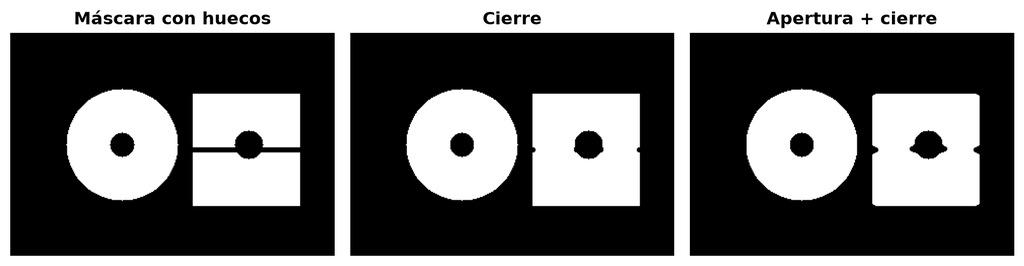

```python
import numpy as np
import cv2
import matplotlib.pyplot as plt

# Máscara con objeto principal + huecos/cortes artificiales
mask_obj = np.zeros((220, 320), dtype=np.uint8)
cv2.circle(mask_obj, (110, 110), 55, 255, -1)
cv2.rectangle(mask_obj, (180, 60), (285, 170), 255, -1)

# Creamos huecos negros y un corte
cv2.circle(mask_obj, (110, 110), 12, 0, -1)
cv2.circle(mask_obj, (235, 110), 14, 0, -1)
cv2.line(mask_obj, (180, 115), (285, 115), 0, 4)

kernel = cv2.getStructuringElement(cv2.MORPH_ELLIPSE, (7, 7))
closed = cv2.morphologyEx(mask_obj, cv2.MORPH_CLOSE, kernel, iterations=1)
opened_then_closed = cv2.morphologyEx(
        cv2.morphologyEx(mask_obj, cv2.MORPH_OPEN, kernel, iterations=1),
        cv2.MORPH_CLOSE,
        kernel,
        iterations=1,
)

fig, axs = plt.subplots(1, 3, figsize=(10, 4))
axs[0].imshow(mask_obj, cmap="gray")
axs[0].set_title("Máscara con huecos", fontweight="bold")
axs[0].axis("off")

axs[1].imshow(closed, cmap="gray")
axs[1].set_title("Cierre", fontweight="bold")
axs[1].axis("off")

axs[2].imshow(opened_then_closed, cmap="gray")
axs[2].set_title("Apertura + cierre", fontweight="bold")
axs[2].axis("off")

plt.tight_layout()
plt.show()
```

## 12 Refinamiento de máscara (caso `frutas.jpg`)

Operación recomendada después de segmentar:

- **Apertura**: elimina ruido pequeño (erosión + dilatación).
- **Cierre**: rellena huecos pequeños (dilatación + erosión).

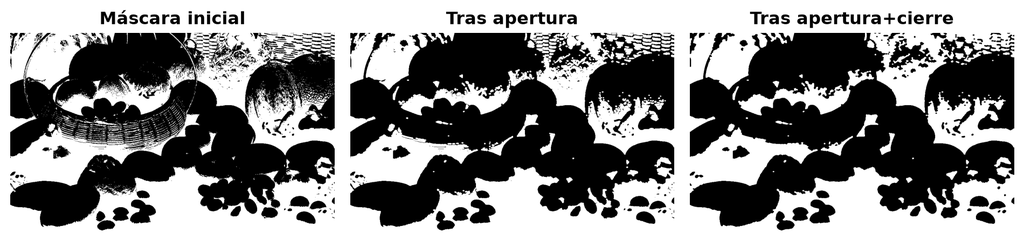

```python
import cv2
import matplotlib.pyplot as plt

kernel = cv2.getStructuringElement(cv2.MORPH_ELLIPSE, (5, 5))
mask_open = cv2.morphologyEx(mask, cv2.MORPH_OPEN, kernel, iterations=1)
mask_ref = cv2.morphologyEx(mask_open, cv2.MORPH_CLOSE, kernel, iterations=1)

fig, axs = plt.subplots(1, 3, figsize=(10, 4))
axs[0].imshow(mask, cmap="gray")
axs[0].set_title("Máscara inicial", fontweight="bold")
axs[0].axis("off")

axs[1].imshow(mask_open, cmap="gray")
axs[1].set_title("Tras apertura", fontweight="bold")
axs[1].axis("off")

axs[2].imshow(mask_ref, cmap="gray")
axs[2].set_title("Tras apertura+cierre", fontweight="bold")
axs[2].axis("off")

plt.tight_layout()
plt.show()
```

## 13 Comparación de métodos (para discusión)

- **Discontinuidades (bordes)**: destacan cambios bruscos de intensidad.
- **Similaridad (umbralización global/adaptativa)**: generan máscaras por criterio de intensidad.
- **Agrupamiento (k-means)**: separa clases de intensidad sin fijar un único umbral.

## 14 Ejemplo completo integrador: `DPP0357.TIF`

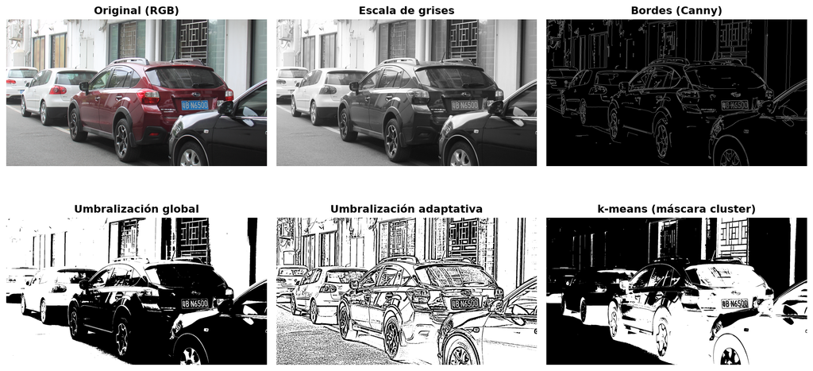

```
Centros de k-means (intensidad): [ 51 145 225]
```

```python
import cv2
import numpy as np
import matplotlib.pyplot as plt

# 1) Carga de imagen (distinta de frutas)
img_bgr = cv2.imread("imagenes/DPP0357.TIF")
if img_bgr is None:
    raise FileNotFoundError("No se encontró la imagen en 'imagenes/DPP0357.TIF'")

img_gray = cv2.cvtColor(img_bgr, cv2.COLOR_BGR2GRAY)

# 2) Segmentación basada en discontinuidades (bordes)
img_blur = cv2.GaussianBlur(img_gray, (5, 5), 1.2)
edges = cv2.Canny(img_blur, 70, 150)

# 3) Segmentación por similaridad
# 3a) Umbralización global (manual)
_, th_global = cv2.threshold(img_gray, 120, 255, cv2.THRESH_BINARY)

# 3b) Umbralización adaptativa
th_adapt = cv2.adaptiveThreshold(
    img_gray,
    255,
    cv2.ADAPTIVE_THRESH_GAUSSIAN_C,
    cv2.THRESH_BINARY,
    31,
    4,
)

# 4) Segmentación por agrupamiento (k-means en intensidades)
Z = img_gray.reshape((-1, 1)).astype(np.float32)
criteria = (cv2.TERM_CRITERIA_EPS + cv2.TERM_CRITERIA_MAX_ITER, 40, 0.1)
_, labels, centers = cv2.kmeans(
    Z,
    3,
    None,
    criteria,
    12,
    cv2.KMEANS_PP_CENTERS,
)

centers = np.uint8(centers)
labels2d = labels.reshape(img_gray.shape)
seg_kmeans = centers[labels.flatten()].reshape(img_gray.shape)

# Máscara de ejemplo: cluster más oscuro
obj_id = int(np.argmin(centers))
mask_kmeans = (labels2d == obj_id).astype(np.uint8) * 255

# 5) Visualización comparativa
fig, axs = plt.subplots(2, 3, figsize=(13, 7))

axs[0, 0].imshow(cv2.cvtColor(img_bgr, cv2.COLOR_BGR2RGB))
axs[0, 0].set_title("Original (RGB)", fontweight="bold")
axs[0, 0].axis("off")

axs[0, 1].imshow(img_gray, cmap="gray")
axs[0, 1].set_title("Escala de grises", fontweight="bold")
axs[0, 1].axis("off")

axs[0, 2].imshow(edges, cmap="gray")
axs[0, 2].set_title("Bordes (Canny)", fontweight="bold")
axs[0, 2].axis("off")

axs[1, 0].imshow(th_global, cmap="gray")
axs[1, 0].set_title("Umbralización global", fontweight="bold")
axs[1, 0].axis("off")

axs[1, 1].imshow(th_adapt, cmap="gray")
axs[1, 1].set_title("Umbralización adaptativa", fontweight="bold")
axs[1, 1].axis("off")

axs[1, 2].imshow(mask_kmeans, cmap="gray")
axs[1, 2].set_title("k-means (máscara cluster)", fontweight="bold")
axs[1, 2].axis("off")

plt.tight_layout()
plt.show()

print("Centros de k-means (intensidad):", np.sort(centers.ravel()))
```

## 15 Lectura rápida del ejemplo

- **Bordes (Canny)**: útil para contornos, no separa por sí solo objeto/fondo completo.
- **Global**: simple y rápido, pero sensible a cambios de iluminación.
- **Adaptativa**: mejora zonas con iluminación desigual, a costa de más ruido local.
- **k-means**: ofrece una partición por clases de intensidad; requiere interpretar qué cluster representa el objeto de interés.

## 16 Ejemplo completo integrador 2: `DPP0029.TIF`

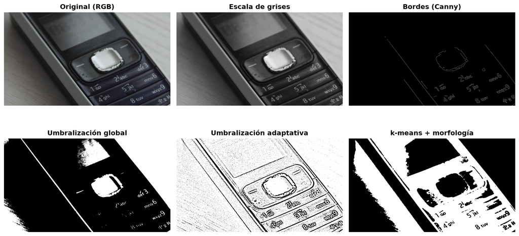

```
Centros de k-means (intensidad): [ 44  98 180]
```

```python
import cv2
import numpy as np
import matplotlib.pyplot as plt

# 1) Carga de segunda imagen TIF
img_bgr2 = cv2.imread("imagenes/DPP0029.TIF")
if img_bgr2 is None:
    raise FileNotFoundError("No se encontró la imagen en 'imagenes/DPP0029.TIF'")

img_gray2 = cv2.cvtColor(img_bgr2, cv2.COLOR_BGR2GRAY)

# 2) Discontinuidades (bordes)
blur2 = cv2.GaussianBlur(img_gray2, (5, 5), 1.0)
edges2 = cv2.Canny(blur2, 60, 140)

# 3) Similaridad
_, th_global2 = cv2.threshold(img_gray2, 125, 255, cv2.THRESH_BINARY)
th_adapt2 = cv2.adaptiveThreshold(
        img_gray2,
        255,
        cv2.ADAPTIVE_THRESH_GAUSSIAN_C,
        cv2.THRESH_BINARY,
        35,
        5,
)

# 4) Agrupamiento por intensidades (k-means)
Z2 = img_gray2.reshape((-1, 1)).astype(np.float32)
criteria2 = (cv2.TERM_CRITERIA_EPS + cv2.TERM_CRITERIA_MAX_ITER, 45, 0.1)
_, labels2, centers2 = cv2.kmeans(
        Z2,
        3,
        None,
        criteria2,
        15,
        cv2.KMEANS_PP_CENTERS,
)

centers2 = np.uint8(centers2)
labels2d_2 = labels2.reshape(img_gray2.shape)

# Cluster de interés: menor intensidad (ajustable según objetivo)
obj_id2 = int(np.argmin(centers2))
mask_kmeans2 = (labels2d_2 == obj_id2).astype(np.uint8) * 255

# Refinamiento opcional para análisis posterior
kernel2 = cv2.getStructuringElement(cv2.MORPH_ELLIPSE, (5, 5))
mask_kmeans2_ref = cv2.morphologyEx(mask_kmeans2, cv2.MORPH_OPEN, kernel2, iterations=1)
mask_kmeans2_ref = cv2.morphologyEx(mask_kmeans2_ref, cv2.MORPH_CLOSE, kernel2, iterations=1)

# 5) Comparación visual
fig, axs = plt.subplots(2, 3, figsize=(13, 7))

axs[0, 0].imshow(cv2.cvtColor(img_bgr2, cv2.COLOR_BGR2RGB))
axs[0, 0].set_title("Original (RGB)", fontweight="bold")
axs[0, 0].axis("off")

axs[0, 1].imshow(img_gray2, cmap="gray")
axs[0, 1].set_title("Escala de grises", fontweight="bold")
axs[0, 1].axis("off")

axs[0, 2].imshow(edges2, cmap="gray")
axs[0, 2].set_title("Bordes (Canny)", fontweight="bold")
axs[0, 2].axis("off")

axs[1, 0].imshow(th_global2, cmap="gray")
axs[1, 0].set_title("Umbralización global", fontweight="bold")
axs[1, 0].axis("off")

axs[1, 1].imshow(th_adapt2, cmap="gray")
axs[1, 1].set_title("Umbralización adaptativa", fontweight="bold")
axs[1, 1].axis("off")

axs[1, 2].imshow(mask_kmeans2_ref, cmap="gray")
axs[1, 2].set_title("k-means + morfología", fontweight="bold")
axs[1, 2].axis("off")

plt.tight_layout()
plt.show()

print("Centros de k-means (intensidad):", np.sort(centers2.ravel()))
```

## 17 ¿Cómo argumentar decisiones técnicas?

Para justificar una segmentación en función de **descripción** y **reconocimiento**, reporta evidencia concreta:

- **Separación objeto/fondo**:
  - ¿El objeto de interés queda completo o fragmentado?
  - ¿El fondo introduce falsos positivos?
- **Calidad geométrica de la máscara**:
  - continuidad de contornos,
  - cantidad de huecos internos,
  - presencia de ruido fino.
- **Estabilidad para descriptores**:
  - descriptores de forma (área, perímetro, circularidad) son sensibles a bordes ruidosos,
  - descriptores de textura/intensidad son sensibles a fuga de fondo.
- **Impacto esperado en reconocimiento**:
  - segmentaciones limpias reducen variabilidad intra-clase,
  - menos ruido mejora consistencia entre muestras,
  - fragmentación puede degradar clasificación o conteo.

Formato breve sugerido para tu informe:

1. Método y parámetros exactos.
2. Evidencia visual comparativa (misma escala/layout).
3. Riesgos observados (ruido, pérdida de objeto, sobresegmentación).
4. Decisión final y justificación orientada al objetivo de reconocimiento.

## 18 Práctica integradora de la Unidad 3

Esta práctica reúne los conceptos de **bordes**, **umbralización**, **agrupamiento** y **morfología** en un mismo flujo de trabajo. La pregunta central no es qué método es universalmente mejor, sino:

> ¿Qué información de la imagen aprovecha cada método y en qué tipo de escena conviene utilizarlo?

| Imagen | Situación que permite discutir |
| --- | --- |
| `frutas.jpg` | objetos y colores diferentes; la conversión a gris pierde información |
| `gato.jpeg` | contornos y textura; puede haber muchos bordes que no son el objeto |
| `DPP0357.TIF` | imagen con estructuras y contrastes locales |
| `DPP0029.TIF` | escena con variaciones de iluminación y regiones de intensidad |
| `radiografia.jpg` | bajo contraste, estructuras superpuestas y bordes anatómicos internos |

El flujo será deliberadamente constante para que la comparación sea justa:

1. inspeccionar la imagen original y su histograma;
2. detectar discontinuidades con Canny;
3. segmentar por umbral global con Otsu;
4. segmentar con umbral adaptativo;
5. segmentar por k-means con $K=3$;
6. refinar una máscara con apertura y cierre;
7. comparar resultados y justificar una elección.

### 18.1 Reconocimiento visual del banco de imágenes

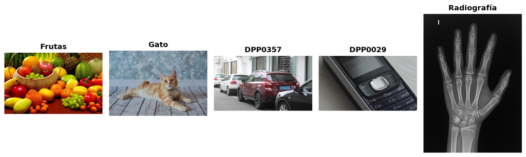

```python
from pathlib import Path
import cv2
import matplotlib.pyplot as plt

archivos = [
    ("frutas.jpg", "Frutas"),
    ("gato.jpeg", "Gato"),
    ("DPP0357.TIF", "DPP0357"),
    ("DPP0029.TIF", "DPP0029"),
    ("radiografia.jpg", "Radiografía"),
]

fig, axs = plt.subplots(1, len(archivos), figsize=(12, 4))
for ax, (nombre, titulo) in zip(axs, archivos):
    ruta = Path("imagenes") / nombre
    imagen = cv2.imread(str(ruta), cv2.IMREAD_COLOR)
    if imagen is None:
        raise FileNotFoundError(f"No se encontró la imagen: {ruta}")
    imagen_rgb = cv2.cvtColor(imagen, cv2.COLOR_BGR2RGB)
    ax.imshow(imagen_rgb)
    ax.set_title(titulo, fontweight="bold")
    ax.axis("off")

plt.tight_layout()
plt.show()
```

### 18.2 Función común de comparación

La función siguiente aplica los mismos métodos a cada imagen. Para k-means se muestra la imagen cuantizada y se elige como máscara de trabajo el grupo con menor intensidad. Esta elección es una **hipótesis**, no una verdad del problema: en una imagen distinta podría ser necesario seleccionar otro grupo.

```python
import numpy as np
import cv2
import matplotlib.pyplot as plt

def comparar_metodos(ruta, titulo, mostrar=True):
    imagen_bgr = cv2.imread(str(ruta), cv2.IMREAD_COLOR)
    if imagen_bgr is None:
        raise FileNotFoundError(f"No se encontró la imagen: {ruta}")

    gris = cv2.cvtColor(imagen_bgr, cv2.COLOR_BGR2GRAY)
    suavizada = cv2.GaussianBlur(gris, (5, 5), 1.0)

    # 1) Bordes: localizan cambios, pero no producen necesariamente una región cerrada.
    bordes = cv2.Canny(suavizada, 60, 140)

    # 2) Umbral global automático: supone que el histograma permite separar clases.
    umbral_otsu, mascara_otsu = cv2.threshold(
        gris, 0, 255, cv2.THRESH_BINARY + cv2.THRESH_OTSU
    )

    # 3) Umbral local: útil cuando la iluminación cambia dentro de la imagen.
    mascara_adaptativa = cv2.adaptiveThreshold(
        gris,
        255,
        cv2.ADAPTIVE_THRESH_GAUSSIAN_C,
        cv2.THRESH_BINARY,
        31,
        5,
    )

    # 4) K-means sobre intensidades, con tres grupos.
    datos = gris.reshape((-1, 1)).astype(np.float32)
    criterio = (cv2.TERM_CRITERIA_EPS + cv2.TERM_CRITERIA_MAX_ITER, 40, 0.1)
    compactness, etiquetas, centros = cv2.kmeans(
        datos, 3, None, criterio, 10, cv2.KMEANS_PP_CENTERS
    )
    centros = centros.ravel()
    cuantizada = centros[etiquetas.ravel()].reshape(gris.shape).astype(np.uint8)
    grupo_oscuro = int(np.argmin(centros))
    mascara_kmeans = (
        (etiquetas.reshape(gris.shape) == grupo_oscuro).astype(np.uint8) * 255
    )

    # 5) Refinamiento morfológico de la máscara elegida.
    kernel = cv2.getStructuringElement(cv2.MORPH_ELLIPSE, (5, 5))
    mascara_refinada = cv2.morphologyEx(
        mascara_kmeans, cv2.MORPH_OPEN, kernel, iterations=1
    )
    mascara_refinada = cv2.morphologyEx(
        mascara_refinada, cv2.MORPH_CLOSE, kernel, iterations=1
    )

    resultados = {
        "original": cv2.cvtColor(imagen_bgr, cv2.COLOR_BGR2RGB),
        "gris": gris,
        "bordes": bordes,
        "otsu": mascara_otsu,
        "adaptativa": mascara_adaptativa,
        "kmeans": cuantizada,
        "refinada": mascara_refinada,
    }

    if mostrar:
        fig, axs = plt.subplots(2, 4, figsize=(14, 9))
        vistas = [
            (resultados["original"], "Original", None),
            (resultados["gris"], "Escala de grises", "gray"),
            (resultados["bordes"], "Canny", "gray"),
            (resultados["otsu"], f"Otsu (T={umbral_otsu:.0f})", "gray"),
            (resultados["adaptativa"], "Umbral adaptativo", "gray"),
            (resultados["kmeans"], "K-means (K=3)", "gray"),
            (resultados["refinada"], "K-means + morfología", "gray"),
        ]
        for ax, (imagen, subtitulo, mapa) in zip(axs.ravel(), vistas):
            ax.imshow(imagen, cmap=mapa)
            ax.set_title(subtitulo, fontweight="bold")
            ax.axis("off")
        axs[1, 3].axis("off")
        fig.suptitle(titulo, fontsize=15, fontweight="bold")
        plt.tight_layout()
        plt.show()

    return resultados, {
        "otsu": float(umbral_otsu),
        "centros_kmeans": np.sort(centros),
        "compactness": float(compactness),
    }
```

### 18.3 Comparación de las cinco imágenes

La siguiente celda genera una figura por imagen. Conviene observar primero los resultados sin intentar decidir todavía cuál es “el mejor”.

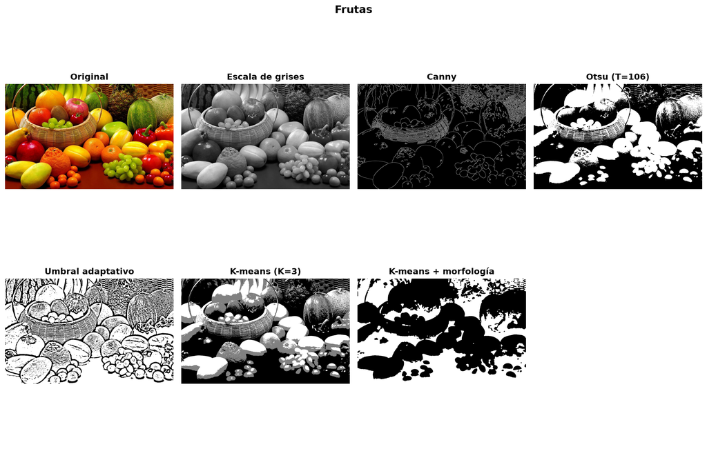

```
frutas.jpg: Otsu=106.0; centros k-means=[ 44.8 114.6 182.4]
```

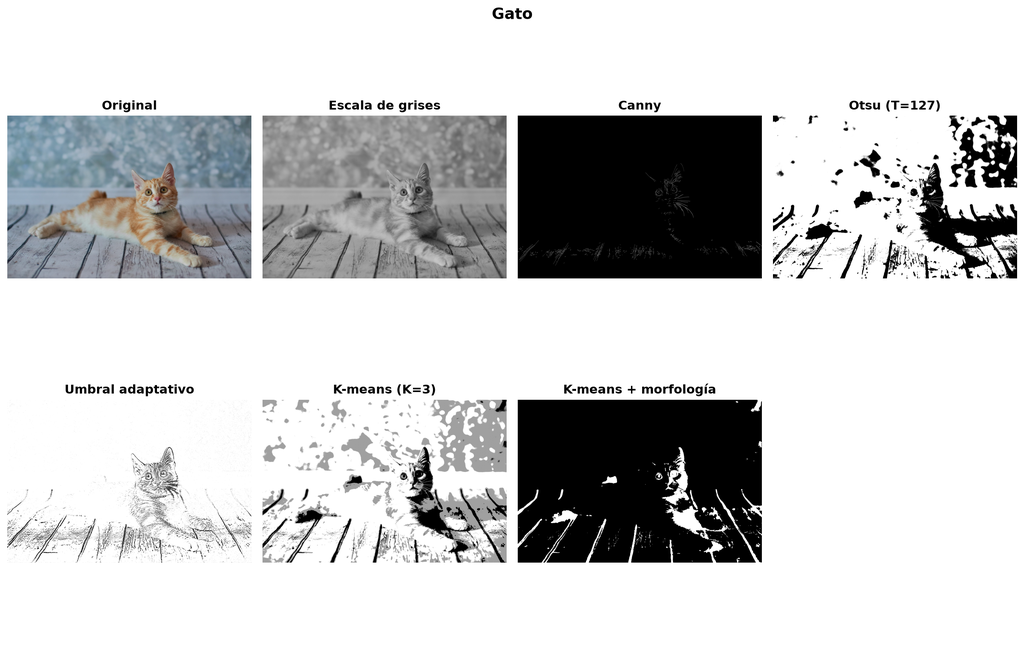

```
gato.jpeg: Otsu=127.0; centros k-means=[ 76.5 121.8 149. ]
```

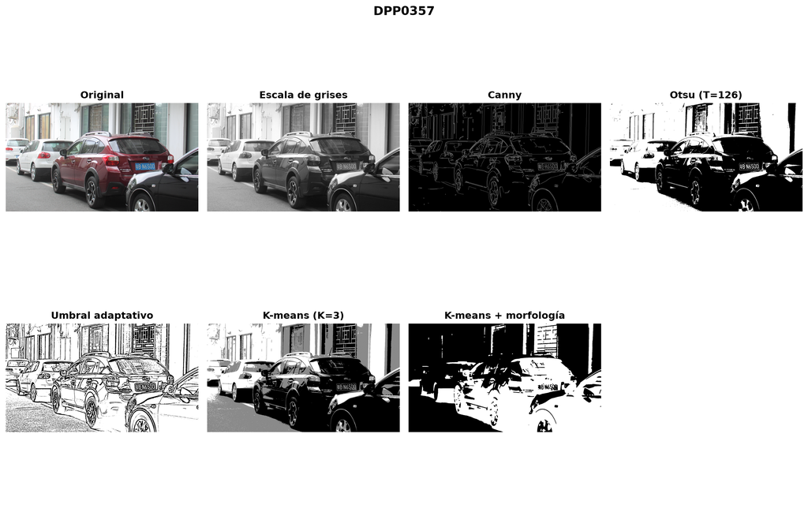

```
DPP0357.TIF: Otsu=126.0; centros k-means=[ 51.1 145.4 225.2]
```

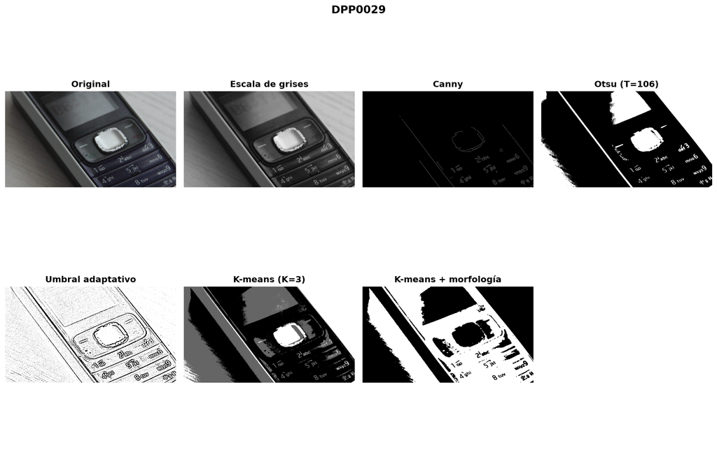

```
DPP0029.TIF: Otsu=106.0; centros k-means=[ 44.5  98.9 180.2]
```

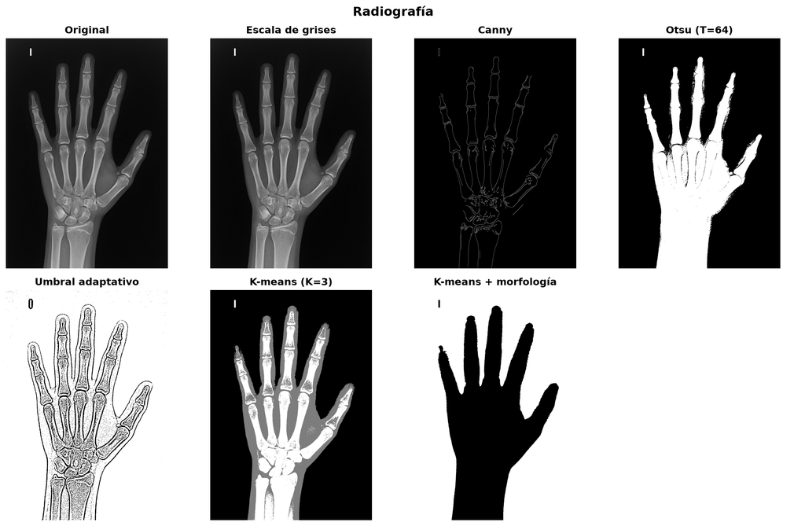

```
radiografia.jpg: Otsu=64.0; centros k-means=[ 13.1  71.3 131.4]
```

```python
from pathlib import Path

resultados_banco = {}
for nombre, titulo in archivos:
    resultados_banco[nombre], parametros = comparar_metodos(
        Path("imagenes") / nombre, titulo
    )
    print(
        f"{nombre}: Otsu={parametros['otsu']:.1f}; "
        f"centros k-means={parametros['centros_kmeans'].round(1)}"
    )
```

### 18.4 Una medida sencilla para no depender solo de la apariencia

Estas medidas no sustituyen la inspección visual ni una máscara de referencia. Sirven para detectar comportamientos que conviene discutir: una máscara con demasiados píxeles blancos puede estar incluyendo casi todo el fondo, mientras que una máscara muy pequeña puede haber perdido el objeto.

```python
def resumen_mascaras(resultados):
    nombres = ["otsu", "adaptativa", "refinada"]
    filas = []
    for nombre in nombres:
        mascara = resultados[nombre]
        porcentaje_blanco = 100 * np.mean(mascara > 0)
        componentes, _, estadisticas, _ = cv2.connectedComponentsWithStats(
            (mascara > 0).astype(np.uint8), connectivity=8
        )
        area_mayor = (
            np.max(estadisticas[1:, cv2.CC_STAT_AREA])
            if componentes > 1
            else 0
        )
        filas.append((nombre, porcentaje_blanco, componentes - 1, area_mayor))
    return filas

for nombre, resultados in resultados_banco.items():
    print(f"\n{nombre}")
    print("método       % blanco   componentes   área mayor")
    for metodo, porcentaje, componentes, area_mayor in resumen_mascaras(resultados):
        print(f"{metodo:12} {porcentaje:8.2f} {componentes:13d} {area_mayor:11d}")
```

```
frutas.jpg
método       % blanco   componentes   área mayor
otsu            43.13          1338      140744
adaptativa      69.43          1095      123181
refinada        41.22            78      122266

gato.jpeg
método       % blanco   componentes   área mayor
otsu            76.10          8327     7574152
adaptativa      95.19          1544    10120389
refinada         6.76           290      158059

DPP0357.TIF
método       % blanco   componentes   área mayor
otsu            50.02           693      718938
adaptativa      75.26           941      710518
refinada        41.11           100      718500

DPP0029.TIF
método       % blanco   componentes   área mayor
otsu            29.18           681      263478
adaptativa      88.58           686     1197651
refinada        48.87            44      760793

radiografia.jpg
método       % blanco   componentes   área mayor
otsu            27.95           474      480917
adaptativa      89.02           351     1531985
refinada        65.10             1     1198267
```

### 18.5 Preguntas de análisis

Para cada imagen, responde en Markdown:

1. ¿Qué estructuras aparecen en Canny? ¿Son contornos útiles o también textura y ruido?
2. ¿Otsu separa razonablemente el objeto y el fondo? Relaciona la respuesta con el histograma.
3. ¿La máscara adaptativa mejora alguna zona con iluminación desigual? ¿Qué ruido introduce?
4. ¿Qué representan los tres centros de k-means? ¿Es correcto elegir siempre el grupo más oscuro?
5. ¿Qué cambió después de apertura y cierre: ruido, huecos, fragmentación o tamaño del objeto?
6. Elige un método para cada imagen y justifica la decisión con al menos dos evidencias visuales y una medida de la tabla.

### 18.6 Reto de extensión

Repite la comparación usando una de estas variantes:

- k-means con $K=2$ y $K=4$;
- Canny con dos pares de umbrales;
- umbral adaptativo con `blockSize=15` y `blockSize=51`;
- k-means usando píxeles de color en lugar de intensidades;
- una máscara distinta como objetivo, seleccionando manualmente otro centroide.

El resultado final debe incluir la figura comparativa, los parámetros utilizados, una tabla breve y una conclusión sobre qué método es más adecuado para el objetivo elegido: localizar contornos, separar regiones o preparar una imagen para descriptores posteriores.

## 19 Aplicaciones de las técnicas de la Unidad 3

Las técnicas estudiadas aparecen en muchas cadenas de procesamiento de imágenes. En una aplicación real, normalmente se combinan: primero se mejora o suaviza la imagen, después se localizan bordes o regiones, y finalmente se extraen medidas para inspección, clasificación o apoyo a una decisión.

| Técnica | Qué aporta | Aplicaciones posibles |
| --- | --- | --- |
| Sobel / Canny | localización de cambios y contornos | inspección de piezas, lectura de formas, detección de límites anatómicos |
| Umbral global / Otsu | separación rápida de dos clases de intensidad | documentos escaneados, objetos sobre fondo uniforme, conteo de componentes |
| Umbral adaptativo | separación con iluminación desigual | documentos con sombras, microscopía, superficies no uniformes |
| K-means | agrupamiento de píxeles por intensidad o color | cuantización, separación de tejidos o materiales, presegmentación |
| Apertura / cierre | eliminación de ruido y reparación de máscaras | limpieza de objetos detectados, unión de regiones, relleno de huecos |

### 19.1 Caso aplicado: radiografía de la mano

La radiografía incluida en el banco permite discutir varias tareas posibles:

- **Visualización de estructuras óseas:** Canny puede resaltar corticales, articulaciones y contornos, aunque también puede producir muchos bordes internos por la textura del hueso.
- **Separación hueso/fondo:** Otsu o k-means pueden generar una primera máscara de las zonas radiopacas. El resultado depende del contraste y no debe interpretarse como una segmentación clínica definitiva.
- **Análisis de articulaciones:** una máscara o un mapa de bordes puede servir como etapa previa para localizar regiones de interés, medir separaciones o comparar imágenes bajo un protocolo controlado.
- **Control de calidad:** las mismas técnicas pueden ayudar a detectar una imagen demasiado oscura, saturada, movida o con contraste insuficiente antes de enviarla a un sistema de análisis.

En este caso conviene comparar dos objetivos distintos:

1. **Segmentar la mano completa:** el umbral global o k-means pueden ser suficientes para separar la silueta del fondo oscuro.
2. **Encontrar una fractura o una articulación:** la tarea es más difícil; Canny, el análisis local y métodos posteriores serían más informativos que quedarse con el grupo más oscuro o más claro de k-means.

La práctica no realiza diagnóstico médico. Su objetivo es mostrar cómo el objetivo de análisis determina qué método, parámetros y evidencia deben seleccionarse.

### 19.2 Otras áreas de aplicación

**Inspección industrial.** Los bordes permiten encontrar grietas, soldaduras, contornos o defectos geométricos. La umbralización puede separar una pieza de su fondo y la morfología puede eliminar pequeñas partículas que no interesan.

**Documentos y texto.** Otsu funciona bien cuando el papel y la tinta forman dos poblaciones de intensidad. El umbral adaptativo resulta preferible cuando hay sombras, arrugas o iluminación desigual. Canny puede ayudar a encontrar límites de caracteres, aunque no siempre es el mejor método para leerlos.

**Microscopía y biología.** K-means puede separar células, regiones de tejido o niveles de tinción cuando existen grupos de intensidad o color distinguibles. La morfología ayuda a quitar partículas aisladas y conservar objetos con una forma coherente.

**Teledetección.** La segmentación por regiones puede distinguir agua, vegetación, suelo o construcciones cuando sus intensidades o colores son separables. La variación de iluminación y atmósfera hace especialmente importante comparar umbrales globales y locales.

**Robótica y visión industrial.** Los contornos pueden localizar piezas y estimar su orientación; una máscara refinada puede utilizarse después para calcular área, centroide, perímetro o descriptores de forma.

### 19.3 Actividad de transferencia

Elige una de las áreas anteriores y completa la siguiente ficha:

1. ¿Cuál es el objeto o región de interés?
2. ¿Qué dificultad presenta la imagen: ruido, bajo contraste, textura, iluminación desigual o solapamiento?
3. ¿Qué método usarías primero y qué método usarías como respaldo?
4. ¿Qué error sería más grave: perder parte del objeto o incluir fondo?
5. ¿Qué medida o evidencia visual usarías para evaluar el resultado?

Para ampliar las aplicaciones médicas de forma responsable, sería útil contar con un pequeño conjunto adicional de radiografías etiquetadas, por ejemplo **dos o tres imágenes normales y dos o tres con una alteración claramente documentada**, siempre anonimizadas y con permiso de uso. No hace falta añadirlas para esta práctica: la radiografía actual ya es suficiente para estudiar contraste, bordes, segmentación y limitaciones.